```python
import pandas as pd
import numpy as np

CCD = pd.read_csv('creditcard.csv')  #CCD stands for credit card data
CCD.head(10)
```

|  | Time | V1 | V2 | V3 | V4 | V5 | V6 | V7 | V8 | V9 | ... | V21 | V22 | V23 | V24 | V25 | V26 | V27 | V28 | Amount | Class |
| --- | --- | --- | --- | --- | --- | --- | --- | --- | --- | --- | --- | --- | --- | --- | --- | --- | --- | --- | --- | --- | --- |
| 0 | 0.0 | -1.359807 | -0.072781 | 2.536347 | 1.378155 | -0.338321 | 0.462388 | 0.239599 | 0.098698 | 0.363787 | ... | -0.018307 | 0.277838 | -0.110474 | 0.066928 | 0.128539 | -0.189115 | 0.133558 | -0.021053 | 149.62 | 0 |
| 1 | 0.0 | 1.191857 | 0.266151 | 0.166480 | 0.448154 | 0.060018 | -0.082361 | -0.078803 | 0.085102 | -0.255425 | ... | -0.225775 | -0.638672 | 0.101288 | -0.339846 | 0.167170 | 0.125895 | -0.008983 | 0.014724 | 2.69 | 0 |
| 2 | 1.0 | -1.358354 | -1.340163 | 1.773209 | 0.379780 | -0.503198 | 1.800499 | 0.791461 | 0.247676 | -1.514654 | ... | 0.247998 | 0.771679 | 0.909412 | -0.689281 | -0.327642 | -0.139097 | -0.055353 | -0.059752 | 378.66 | 0 |
| 3 | 1.0 | -0.966272 | -0.185226 | 1.792993 | -0.863291 | -0.010309 | 1.247203 | 0.237609 | 0.377436 | -1.387024 | ... | -0.108300 | 0.005274 | -0.190321 | -1.175575 | 0.647376 | -0.221929 | 0.062723 | 0.061458 | 123.50 | 0 |
| 4 | 2.0 | -1.158233 | 0.877737 | 1.548718 | 0.403034 | -0.407193 | 0.095921 | 0.592941 | -0.270533 | 0.817739 | ... | -0.009431 | 0.798278 | -0.137458 | 0.141267 | -0.206010 | 0.502292 | 0.219422 | 0.215153 | 69.99 | 0 |
| 5 | 2.0 | -0.425966 | 0.960523 | 1.141109 | -0.168252 | 0.420987 | -0.029728 | 0.476201 | 0.260314 | -0.568671 | ... | -0.208254 | -0.559825 | -0.026398 | -0.371427 | -0.232794 | 0.105915 | 0.253844 | 0.081080 | 3.67 | 0 |
| 6 | 4.0 | 1.229658 | 0.141004 | 0.045371 | 1.202613 | 0.191881 | 0.272708 | -0.005159 | 0.081213 | 0.464960 | ... | -0.167716 | -0.270710 | -0.154104 | -0.780055 | 0.750137 | -0.257237 | 0.034507 | 0.005168 | 4.99 | 0 |
| 7 | 7.0 | -0.644269 | 1.417964 | 1.074380 | -0.492199 | 0.948934 | 0.428118 | 1.120631 | -3.807864 | 0.615375 | ... | 1.943465 | -1.015455 | 0.057504 | -0.649709 | -0.415267 | -0.051634 | -1.206921 | -1.085339 | 40.80 | 0 |
| 8 | 7.0 | -0.894286 | 0.286157 | -0.113192 | -0.271526 | 2.669599 | 3.721818 | 0.370145 | 0.851084 | -0.392048 | ... | -0.073425 | -0.268092 | -0.204233 | 1.011592 | 0.373205 | -0.384157 | 0.011747 | 0.142404 | 93.20 | 0 |
| 9 | 9.0 | -0.338262 | 1.119593 | 1.044367 | -0.222187 | 0.499361 | -0.246761 | 0.651583 | 0.069539 | -0.736727 | ... | -0.246914 | -0.633753 | -0.120794 | -0.385050 | -0.069733 | 0.094199 | 0.246219 | 0.083076 | 3.68 | 0 |

10 rows × 31 columns

# DATA EXPLORATION

```python
frauds = CCD[CCD.Class == 1]
normal = CCD[CCD.Class == 0]
print(frauds.shape)
print(normal.shape)
```

```
(492, 31)
(284315, 31)
```

```python
CCD.describe()  #statistical description of each column
```

|  | Time | V1 | V2 | V3 | V4 | V5 | V6 | V7 | V8 | V9 | ... | V21 | V22 | V23 | V24 | V25 | V26 | V27 | V28 | Amount | Class |
| --- | --- | --- | --- | --- | --- | --- | --- | --- | --- | --- | --- | --- | --- | --- | --- | --- | --- | --- | --- | --- | --- |
| count | 284807.000000 | 2.848070e+05 | 2.848070e+05 | 2.848070e+05 | 2.848070e+05 | 2.848070e+05 | 2.848070e+05 | 2.848070e+05 | 2.848070e+05 | 2.848070e+05 | ... | 2.848070e+05 | 2.848070e+05 | 2.848070e+05 | 2.848070e+05 | 2.848070e+05 | 2.848070e+05 | 2.848070e+05 | 2.848070e+05 | 284807.000000 | 284807.000000 |
| mean | 94813.859575 | 1.165980e-15 | 3.416908e-16 | -1.373150e-15 | 2.086869e-15 | 9.604066e-16 | 1.490107e-15 | -5.556467e-16 | 1.177556e-16 | -2.406455e-15 | ... | 1.656562e-16 | -3.444850e-16 | 2.578648e-16 | 4.471968e-15 | 5.340915e-16 | 1.687098e-15 | -3.666453e-16 | -1.220404e-16 | 88.349619 | 0.001727 |
| std | 47488.145955 | 1.958696e+00 | 1.651309e+00 | 1.516255e+00 | 1.415869e+00 | 1.380247e+00 | 1.332271e+00 | 1.237094e+00 | 1.194353e+00 | 1.098632e+00 | ... | 7.345240e-01 | 7.257016e-01 | 6.244603e-01 | 6.056471e-01 | 5.212781e-01 | 4.822270e-01 | 4.036325e-01 | 3.300833e-01 | 250.120109 | 0.041527 |
| min | 0.000000 | -5.640751e+01 | -7.271573e+01 | -4.832559e+01 | -5.683171e+00 | -1.137433e+02 | -2.616051e+01 | -4.355724e+01 | -7.321672e+01 | -1.343407e+01 | ... | -3.483038e+01 | -1.093314e+01 | -4.480774e+01 | -2.836627e+00 | -1.029540e+01 | -2.604551e+00 | -2.256568e+01 | -1.543008e+01 | 0.000000 | 0.000000 |
| 25% | 54201.500000 | -9.203734e-01 | -5.985499e-01 | -8.903648e-01 | -8.486401e-01 | -6.915971e-01 | -7.682956e-01 | -5.540759e-01 | -2.086297e-01 | -6.430976e-01 | ... | -2.283949e-01 | -5.423504e-01 | -1.618463e-01 | -3.545861e-01 | -3.171451e-01 | -3.269839e-01 | -7.083953e-02 | -5.295979e-02 | 5.600000 | 0.000000 |
| 50% | 84692.000000 | 1.810880e-02 | 6.548556e-02 | 1.798463e-01 | -1.984653e-02 | -5.433583e-02 | -2.741871e-01 | 4.010308e-02 | 2.235804e-02 | -5.142873e-02 | ... | -2.945017e-02 | 6.781943e-03 | -1.119293e-02 | 4.097606e-02 | 1.659350e-02 | -5.213911e-02 | 1.342146e-03 | 1.124383e-02 | 22.000000 | 0.000000 |
| 75% | 139320.500000 | 1.315642e+00 | 8.037239e-01 | 1.027196e+00 | 7.433413e-01 | 6.119264e-01 | 3.985649e-01 | 5.704361e-01 | 3.273459e-01 | 5.971390e-01 | ... | 1.863772e-01 | 5.285536e-01 | 1.476421e-01 | 4.395266e-01 | 3.507156e-01 | 2.409522e-01 | 9.104512e-02 | 7.827995e-02 | 77.165000 | 0.000000 |
| max | 172792.000000 | 2.454930e+00 | 2.205773e+01 | 9.382558e+00 | 1.687534e+01 | 3.480167e+01 | 7.330163e+01 | 1.205895e+02 | 2.000721e+01 | 1.559499e+01 | ... | 2.720284e+01 | 1.050309e+01 | 2.252841e+01 | 4.584549e+00 | 7.519589e+00 | 3.517346e+00 | 3.161220e+01 | 3.384781e+01 | 25691.160000 | 1.000000 |

8 rows × 31 columns

```python
print(CCD.isnull().values.any())
```

```
False
```

The test above shows there are no missing values. Now lets look at the distribution of fraudulent and non-fraudlent data.

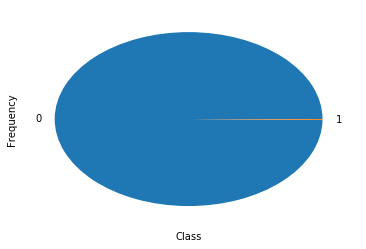

```python
import matplotlib.pyplot as plt
class_count = pd.value_counts(CCD['Class'], sort = True)
class_count.plot(kind = 'pie')
plt.xlabel("Class")
plt.ylabel("Frequency");
plt.show()
```

```python
print("FRAUD TIME DISTRIBUTION")
print(CCD.Time[CCD.Class == 1].describe(), '\n')

print("NON-FRAUD TIME DISTRIBUTION")
print(CCD.Time[CCD.Class == 0].describe(), 'f\n')

print("FRAUD AMOUNT TRANSACTED DISTRIBUTION")
print(CCD.Amount[CCD.Class == 1].describe(),'\n')

print("NON-FRAUD AMOUNT TRANSACTED DISTRIBUTION")
print(CCD.Amount[CCD.Class == 0].describe(), '\n')
```

```
FRAUD TIME DISTRIBUTION
(count       492.000000
mean      80746.806911
std       47835.365138
min         406.000000
25%       41241.500000
50%       75568.500000
75%      128483.000000
max      170348.000000
Name: Time, dtype: float64, '\n')
NON-FRAUD TIME DISTRIBUTION
(count    284315.000000
mean      94838.202258
std       47484.015786
min           0.000000
25%       54230.000000
50%       84711.000000
75%      139333.000000
max      172792.000000
Name: Time, dtype: float64, 'f\n')
FRAUD AMOUNT TRANSACTED DISTRIBUTION
(count     492.000000
mean      122.211321
std       256.683288
min         0.000000
25%         1.000000
50%         9.250000
75%       105.890000
max      2125.870000
Name: Amount, dtype: float64, '\n')
NON-FRAUD AMOUNT TRANSACTED DISTRIBUTION
(count    284315.000000
mean         88.291022
std         250.105092
min           0.000000
25%           5.650000
50%          22.000000
75%          77.050000
max       25691.160000
Name: Amount, dtype: float64, '\n')
```

The above visulation and statistical description of the data shows that it is totally unbalanced (492 to 284315). This means that we have to be careful when computing a accuracy score because even if the model predicts all of the anamolies as normal (i.e. 492 false positives), the ROC analysis would still output high precision and recall scores. So, we should use resampling (specifically undersampling) to bring the balance to a 50/50 ratio. Now, lets continue to explore the data and investigate any relationships between the features.

### Time vs Amount scatterplot

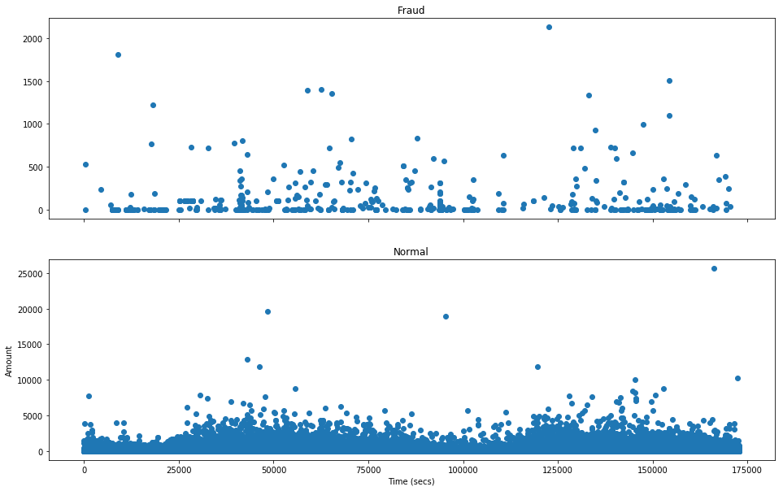

```python
fig, [ax1, ax2] = plt.subplots(2, 1, sharex=True, figsize=(16,10))

ax1.set_title('Fraud')
ax1.scatter(CCD.Time[CCD.Class == 1], CCD.Amount[CCD.Class == 1])

ax2.set_title('Normal')
ax2.scatter(CCD.Time[CCD.Class == 0], CCD.Amount[CCD.Class == 0])

plt.xlabel('Time (secs)')
plt.ylabel('Amount')
plt.show()
```

No apparent relationship between time and dollar-amount of transaction can be discovered from the visualisation above.

### Transaction frequency for Time histogram

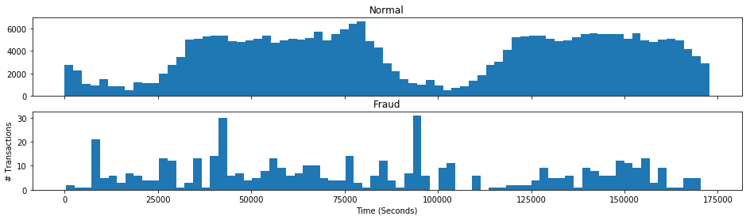

```python
fig, [ax1,ax2] = plt.subplots(2, 1, sharex= True, figsize=(16,4))

ax1.set_title('Normal')
ax1.hist(CCD.Time[CCD.Class == 0], bins = 75)

ax2.set_title('Fraud')
ax2.hist(CCD.Time[CCD.Class == 1], bins = 75)

plt.xlabel('Time (Seconds)')
plt.ylabel('# Transactions')

plt.show()
```

The plot above shows there isn't a relationship between time and the frequency of fradulent/non-fraudulent transactions, except for that normal transactions seems to be cyclical (lows could represent night/sleeping time or off-peak hours vice versa). So the feature time seems not to be very important for our data analysis.

### Transaction frequency for Amount histogram

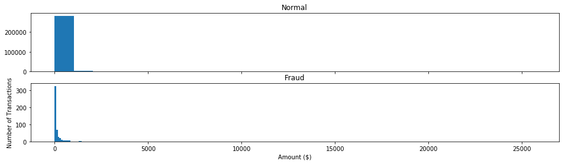

```python
fig, [ax1, ax2] = plt.subplots(2, 1, sharex=True, figsize=(16,4))

ax1.set_title('Normal')
ax1.hist(CCD.Amount[CCD.Class == 0], bins = 25)

ax2.set_title('Fraud')
ax2.hist(CCD.Amount[CCD.Class == 1], bins = 25)

plt.xlabel('Amount ($)')
plt.ylabel('Number of Transactions')
plt.show()
```

We can see that the y-scale is too large for the small amounts to be clearly visible in the visulaisations for the normal transactions, so lets change the scale to logartmic one from a linear one

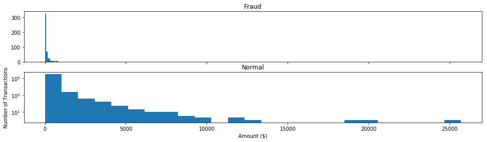

```python
fig, [ax1, ax2] = plt.subplots(2, 1, sharex=True, figsize=(16,4))

ax1.set_title('Fraud')
ax1.hist(CCD.Amount[CCD.Class == 1], bins = 25)

ax2.set_title('Normal')
ax2.hist(CCD.Amount[CCD.Class == 0], bins = 25)

plt.xlabel('Amount ($)')
plt.ylabel('Number of Transactions')
plt.yscale('log')
plt.show()
```

We can now clearly see that there is a relationship between the amount in $ of the transactions and the frequency of non-fraudulent transactions. Although the highest frequency for transactions are both at low amounts for normal and fraudulent transactions, fraudlent transactions seem to have no high-amount transactions while normal transactions do. So this seems to be the distinction amount wise.

Lets have a closer look at dollar-amount of the fraudulent transactions.

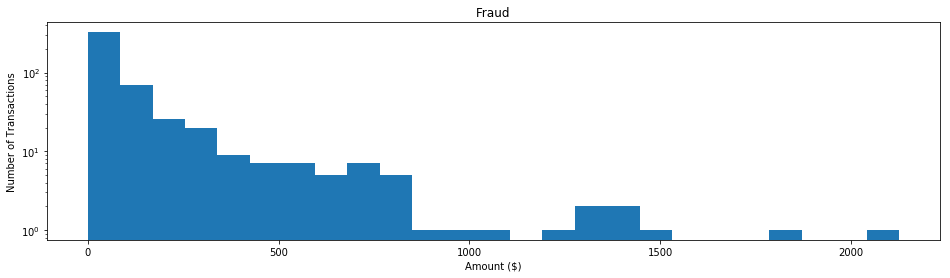

```python
fig, ax = plt.subplots(1, 1, sharex=True, figsize=(16,4))

ax.set_title('Fraud')
ax.hist(CCD.Amount[CCD.Class == 1], bins = 25)

plt.xlabel('Amount ($)')
plt.ylabel('Number of Transactions')
plt.yscale('log')
plt.show()
```

So it is very clear that although there are fraudulent transactions that are big amounts, the bulk of fraudulent transaction are small amounts.

### Anonymised features

Lets investigate the disributions of the anonymised features

[figure not shown]

```python
import seaborn as sns
import matplotlib.gridspec as gridspec

v_features = CCD.ix[:,1:29].columns  #select anonymised features and their class

plt.figure(figsize=(12,28*4))
grid = gridspec.GridSpec(28, 1)


for i, v in enumerate(v_features):
    ax = plt.subplot(grid[i])
    sns.distplot(CCD[v][CCD.Class == 1], bins=75)
    sns.distplot(CCD[v][CCD.Class == 0], bins=75)
    ax.set_title('histogram of feature: ' + str(v))

plt.show()
```

We will drop the features that have very similar distributions for frauduelent and normal transactions, as they won't help us find anomolies in the data. These features would be: V8, V13, V15, V20, V22, V23, V24, V25, V26.

```python
#drop features
CCD2 = CCD.drop(['V8', 'V13', 'V15', 'V20', 'V22', 'V23', 'V24', 'V25', 'V26'], axis = 1)
```

```python
#identifying thresholds that can help us binaries the features
display("Mean: ", CCD2.groupby(("Class")).mean(), "/n", "Median: ", CCD2.groupby(("Class")).median())
```

```
'Mean: '
```

| Class | Time | V1 | V2 | V3 | V4 | V5 | V6 | V7 | V9 | V10 | ... | V12 | V14 | V16 | V17 | V18 | V19 | V21 | V27 | V28 | Amount |
| --- | --- | --- | --- | --- | --- | --- | --- | --- | --- | --- | --- | --- | --- | --- | --- | --- | --- | --- | --- | --- | --- |
| 0 | 94838.202258 | 0.008258 | -0.006271 | 0.012171 | -0.007860 | 0.005453 | 0.002419 | 0.009637 | 0.004467 | 0.009824 | ... | 0.010832 | 0.012064 | 0.007164 | 0.011535 | 0.003887 | -0.001178 | -0.001235 | -0.000295 | -0.000131 | 88.291022 |
| 1 | 80746.806911 | -4.771948 | 3.623778 | -7.033281 | 4.542029 | -3.151225 | -1.397737 | -5.568731 | -2.581123 | -5.676883 | ... | -6.259393 | -6.971723 | -4.139946 | -6.665836 | -2.246308 | 0.680659 | 0.713588 | 0.170575 | 0.075667 | 122.211321 |

2 rows × 21 columns

```
'/n'
```

```
'Median: '
```

| Class | Time | V1 | V2 | V3 | V4 | V5 | V6 | V7 | V9 | V10 | ... | V12 | V14 | V16 | V17 | V18 | V19 | V21 | V27 | V28 | Amount |
| --- | --- | --- | --- | --- | --- | --- | --- | --- | --- | --- | --- | --- | --- | --- | --- | --- | --- | --- | --- | --- | --- |
| 0 | 84711.0 | 0.020023 | 0.064070 | 0.182158 | -0.022405 | -0.053457 | -0.273123 | 0.041138 | -0.049964 | -0.091872 | ... | 0.141679 | 0.051947 | 0.067377 | -0.064833 | -0.002787 | 0.003117 | -0.029821 | 0.001230 | 0.011199 | 22.00 |
| 1 | 75568.5 | -2.342497 | 2.717869 | -5.075257 | 4.177147 | -1.522962 | -1.424616 | -3.034402 | -2.208768 | -4.578825 | ... | -5.502530 | -6.729720 | -3.549795 | -5.302949 | -1.664346 | 0.646807 | 0.592146 | 0.394926 | 0.146344 | 9.25 |

2 rows × 21 columns

### Class correlation

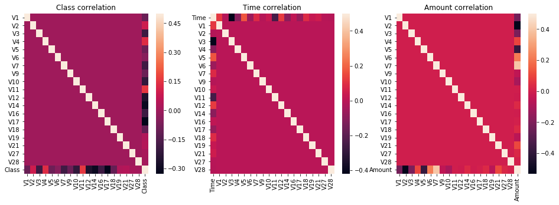

```python
fig, [ax1,ax2,ax3]= plt.subplots(1,3, figsize=(16, 5))
ax1.set_title("Class correlation")
sns.heatmap(CCD2.drop(['Amount','Time'],1).corr(), vmax=.5, ax = ax1)

ax2.set_title("Time correlation")
sns.heatmap(CCD2.drop(['Amount','Class'],1).corr(), vmax=.5, ax = ax2)

ax3.set_title("Amount correlation")
sns.heatmap(CCD2.drop(['Class','Time'],1).corr(), vmax=.5, ax = ax3)
plt.show()
```

There is a class correlation for features uptil V18, but there is pretty much no correaltion for V19 onwards. There is also correlation (although weak) between time and the features until V17. For amount, there is strong correlation for features upto V7. So it seems that we are going to need amount more than time to classify the fraudulent data

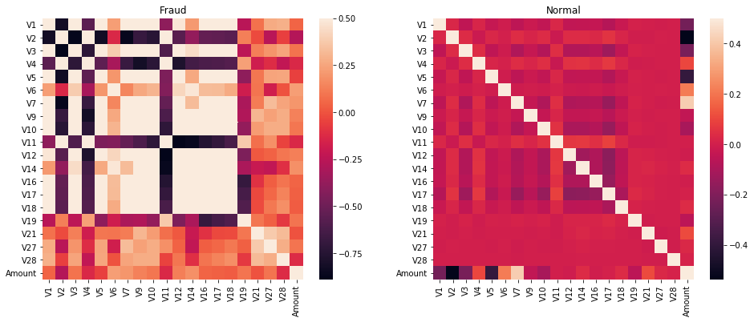

```python
#correlation matrix amount of transaction
fig, [ax1, ax2] = plt.subplots(1,2, figsize = (16,6))

ax1.set_title('Fraud')
sns.heatmap(CCD2[CCD2.Class==1].drop(["Class", "Time"], axis =1).corr(), vmax = .5, ax = ax1)

ax2.set_title('Normal')
sns.heatmap(CCD2[CCD2.Class==0].drop(["Class", "Time"], axis =1).corr(), vmax = .5, ax = ax2)
plt.show()
```

For amount, it seem that the correlation is strong until V19.

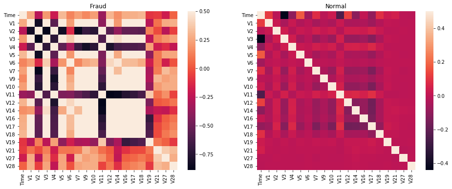

```python
#correlation matrix for time of transaction
fig, [ax1, ax2] = plt.subplots(1,2, figsize = (16,6))

ax1.set_title('Fraud')
sns.heatmap(CCD2[CCD2.Class==1].drop(["Class", "Amount"], axis =1).corr(), vmax = .5, ax = ax1)

ax2.set_title('Normal')
sns.heatmap(CCD2[CCD2.Class==0].drop(["Class", "Amount"], axis =1).corr(), vmax = .5, ax = ax2)
plt.show()
```

# Feature extraction and transformation

```python
CCD3 = CCD2.drop(['V21', 'V27', 'V28'], 1)
```

```python
#identifying thresholds that can help us binaries the features
display("Mean: ", CCD3.groupby(("Class")).mean())
```

```
'Mean: '
```

| Class | Time | V1 | V2 | V3 | V4 | V5 | V6 | V7 | V9 | V10 | V11 | V12 | V14 | V16 | V17 | V18 | V19 | Amount |
| --- | --- | --- | --- | --- | --- | --- | --- | --- | --- | --- | --- | --- | --- | --- | --- | --- | --- | --- |
| 0 | 94838.202258 | 0.008258 | -0.006271 | 0.012171 | -0.007860 | 0.005453 | 0.002419 | 0.009637 | 0.004467 | 0.009824 | -0.006576 | 0.010832 | 0.012064 | 0.007164 | 0.011535 | 0.003887 | -0.001178 | 88.291022 |
| 1 | 80746.806911 | -4.771948 | 3.623778 | -7.033281 | 4.542029 | -3.151225 | -1.397737 | -5.568731 | -2.581123 | -5.676883 | 3.800173 | -6.259393 | -6.971723 | -4.139946 | -6.665836 | -2.246308 | 0.680659 | 122.211321 |

```python
import random

fraud_sample = CCD3[CCD3.Class==1]
normal_data = CCD3[CCD3.Class==0]

normal_data_indices = normal_data.index.tolist()
normal_data_indices = list(map(lambda x: random.choice(normal_data_indices), range(len(fraud_sample))))

normal_sample = normal_data.loc[normal_data_indices]

sample = pd.concat([fraud_sample, normal_sample])
```

```python
sample.head(5)
```

|  | Time | V1 | V2 | V3 | V4 | V5 | V6 | V7 | V9 | V10 | V11 | V12 | V14 | V16 | V17 | V18 | V19 | Amount | Class |
| --- | --- | --- | --- | --- | --- | --- | --- | --- | --- | --- | --- | --- | --- | --- | --- | --- | --- | --- | --- |
| 541 | 406.0 | -2.312227 | 1.951992 | -1.609851 | 3.997906 | -0.522188 | -1.426545 | -2.537387 | -2.770089 | -2.772272 | 3.202033 | -2.899907 | -4.289254 | -1.140747 | -2.830056 | -0.016822 | 0.416956 | 0.00 | 1 |
| 623 | 472.0 | -3.043541 | -3.157307 | 1.088463 | 2.288644 | 1.359805 | -1.064823 | 0.325574 | -0.270953 | -0.838587 | -0.414575 | -0.503141 | -1.692029 | 0.666780 | 0.599717 | 1.725321 | 0.283345 | 529.00 | 1 |
| 4920 | 4462.0 | -2.303350 | 1.759247 | -0.359745 | 2.330243 | -0.821628 | -0.075788 | 0.562320 | -0.238253 | -1.525412 | 2.032912 | -6.560124 | -1.470102 | -2.282194 | -4.781831 | -2.615665 | -1.334441 | 239.93 | 1 |
| 6108 | 6986.0 | -4.397974 | 1.358367 | -2.592844 | 2.679787 | -1.128131 | -1.706536 | -3.496197 | -0.247768 | -4.801637 | 4.895844 | -10.912819 | -6.771097 | -7.358083 | -12.598419 | -5.131549 | 0.308334 | 59.00 | 1 |
| 6329 | 7519.0 | 1.234235 | 3.019740 | -4.304597 | 4.732795 | 3.624201 | -1.357746 | 1.713445 | -1.282858 | -2.447469 | 2.101344 | -4.609628 | -6.079337 | 2.581851 | 6.739384 | 3.042493 | -2.721853 | 1.00 | 1 |

```python
from sklearn.utils import shuffle

sample = shuffle(sample)
sample.head(10)
```

|  | Time | V1 | V2 | V3 | V4 | V5 | V6 | V7 | V9 | V10 | V11 | V12 | V14 | V16 | V17 | V18 | V19 | Amount | Class |
| --- | --- | --- | --- | --- | --- | --- | --- | --- | --- | --- | --- | --- | --- | --- | --- | --- | --- | --- | --- |
| 148170 | 89507.0 | -3.796102 | 3.312477 | -3.615703 | -3.096374 | 3.133422 | 2.579526 | 1.494762 | 3.001280 | 5.203799 | 0.482102 | -0.235202 | -0.859086 | -1.330157 | -0.950021 | -0.852994 | -0.683623 | 7.99 | 0 |
| 15736 | 27163.0 | -23.914101 | 13.765942 | -25.733734 | 6.290918 | -17.784824 | -4.572498 | -17.390764 | -3.819832 | -8.442262 | 5.020112 | -7.046428 | -7.076899 | -6.208238 | -12.532062 | -4.828858 | 0.978636 | 99.99 | 1 |
| 267984 | 163016.0 | -1.171373 | 0.437874 | 1.817463 | -1.829369 | -0.706621 | 0.721984 | -0.780545 | -0.884374 | -0.164934 | -1.786199 | 0.100210 | -0.729087 | -0.318486 | -0.797915 | 2.018724 | -1.089854 | 20.14 | 0 |
| 63758 | 50857.0 | -1.025281 | 1.230708 | 2.924167 | 2.674130 | -0.890106 | 0.466376 | -0.073583 | -0.081292 | 1.592101 | -0.780861 | -1.628462 | -0.233086 | 0.527086 | -0.293612 | 1.000566 | 0.361975 | 35.75 | 0 |
| 250021 | 154684.0 | 2.054147 | 0.169154 | -1.754677 | 0.561303 | 0.090689 | -1.569329 | 0.220090 | 0.722889 | -0.487730 | -0.464198 | -0.432459 | -0.652364 | 0.275497 | 0.531372 | 0.652792 | -0.445449 | 4.00 | 0 |
| 53901 | 46207.0 | 1.318691 | -1.374008 | 0.266557 | -1.574396 | -1.313203 | -0.050566 | -1.041773 | -1.993776 | 1.527533 | 0.544886 | -0.290343 | -0.266796 | 0.261420 | -0.152741 | 0.681796 | 0.341275 | 117.70 | 0 |
| 123301 | 76876.0 | -1.298359 | 1.079671 | -0.180678 | 1.287839 | 1.858273 | -2.223695 | 0.525167 | -0.168893 | -2.544410 | 0.707000 | -0.835696 | -4.993992 | 1.315365 | 3.639200 | 1.623426 | -1.539339 | 1.00 | 1 |
| 15204 | 26556.0 | -19.179826 | 11.817922 | -21.919174 | 6.086236 | -14.708845 | -4.308888 | -15.357952 | -3.999861 | -8.928656 | 5.849293 | -8.261650 | -8.829359 | -7.070953 | -13.629721 | -4.958830 | 1.272091 | 99.99 | 1 |
| 204079 | 135102.0 | 1.862102 | -0.124052 | -1.989752 | 0.382609 | 0.473032 | -0.674517 | 0.298621 | 0.802053 | -0.989431 | -0.491112 | 0.903819 | -1.886162 | 0.086837 | 0.978546 | 0.055604 | 0.189131 | 108.51 | 1 |
| 198552 | 132540.0 | -0.552969 | 0.358830 | 1.366050 | -1.264321 | 0.492044 | -0.222841 | 0.242110 | 0.283898 | -0.930664 | -1.459237 | -0.578711 | -0.123916 | 0.843446 | -1.015805 | 0.361336 | -0.872518 | 0.01 | 0 |

Tranformed data might be useful for logistic regression.

```python
#T stands for transformed
sampleT = pd.DataFrame()

sampleT["V1"] = sample.V1.map(lambda x: 1 if x < -3 else 0)
sampleT["V2"] = sample.V2.map(lambda x: 1 if x > 3 else 0)
sampleT["V3"] = sample.V3.map(lambda x: 1 if x < -3.5 else 0)
sampleT["V4"] = sample.V4.map(lambda x: 1 if x > 2 else 0)
sampleT["V5"] = sample.V5.map(lambda x: 1 if x < -4 else 0)
sampleT["V6"] = sample.V6.map(lambda x: 1 if x < -2.5 else 0)
sampleT["V7"] = sample.V7.map(lambda x: 1 if x < -3 else 0)
sample["V9"] = sample.V9.map(lambda x: 1 if x < -2 else 0)
sampleT["V10"] = sample.V10.map(lambda x: 1 if x < -2.5 else 0)
sampleT["V11"] = sample.V11.map(lambda x: 1 if x > 2 else 0)
sampleT["V12"] = sample.V12.map(lambda x: 1 if x < -2 else 0)
sampleT["V14"] = sample.V14.map(lambda x: 1 if x < -2.5 else 0)
sampleT["V16"] = sample.V16.map(lambda x: 1 if x < --2.5 else 0)
sampleT["V17"] = sample.V17.map(lambda x: 1 if x < -1.5 else 0)
sampleT["V18"] = sample.V18.map(lambda x: 1 if x < -2 else 0)
sampleT["V19"] = sample.V19.map(lambda x: 1 if x > 0.5 else 0)
sampleT["Amount"] = sample.Amount
sampleT["Class"] = sample.Class

#time is not added as we saw it not be relevant before

sampleT.head(10)
```

|  | V1 | V2 | V3 | V4 | V5 | V6 | V7 | V10 | V11 | V12 | V14 | V16 | V17 | V18 | V19 | Amount | Class |
| --- | --- | --- | --- | --- | --- | --- | --- | --- | --- | --- | --- | --- | --- | --- | --- | --- | --- |
| 148170 | 1 | 1 | 1 | 0 | 0 | 0 | 0 | 0 | 0 | 0 | 0 | 1 | 0 | 0 | 0 | 7.99 | 0 |
| 15736 | 1 | 1 | 1 | 1 | 1 | 1 | 1 | 1 | 1 | 1 | 1 | 1 | 1 | 1 | 1 | 99.99 | 1 |
| 267984 | 0 | 0 | 0 | 0 | 0 | 0 | 0 | 0 | 0 | 0 | 0 | 1 | 0 | 0 | 0 | 20.14 | 0 |
| 63758 | 0 | 0 | 0 | 1 | 0 | 0 | 0 | 0 | 0 | 0 | 0 | 1 | 0 | 0 | 0 | 35.75 | 0 |
| 250021 | 0 | 0 | 0 | 0 | 0 | 0 | 0 | 0 | 0 | 0 | 0 | 1 | 0 | 0 | 0 | 4.00 | 0 |
| 53901 | 0 | 0 | 0 | 0 | 0 | 0 | 0 | 0 | 0 | 0 | 0 | 1 | 0 | 0 | 0 | 117.70 | 0 |
| 123301 | 0 | 0 | 0 | 0 | 0 | 0 | 0 | 1 | 0 | 0 | 1 | 1 | 0 | 0 | 0 | 1.00 | 1 |
| 15204 | 1 | 1 | 1 | 1 | 1 | 1 | 1 | 1 | 1 | 1 | 1 | 1 | 1 | 1 | 1 | 99.99 | 1 |
| 204079 | 0 | 0 | 0 | 0 | 0 | 0 | 0 | 0 | 0 | 0 | 0 | 1 | 0 | 0 | 0 | 108.51 | 1 |
| 198552 | 0 | 0 | 0 | 0 | 0 | 0 | 0 | 0 | 0 | 0 | 0 | 1 | 0 | 0 | 0 | 0.01 | 0 |

# Building models

```python
from sklearn.model_selection import train_test_split

X = sample.drop(["Class"],1)
y = sample.Class

X_train, X_test, y_train, y_test = train_test_split(X, y, train_size = .3, test_size = .7, random_state=42)
```

### Logistic regression

```python
from sklearn.linear_model import LogisticRegression
from sklearn.metrics import recall_score
from sklearn.metrics import precision_score
from sklearn.metrics import fbeta_score

def test_LR(C_val):
    clf1 = LogisticRegression(C = C_val)
    clf1.fit(X_train, y_train)

    y_pred = clf1.predict(X_test)

    recall = recall_score(y_test, y_pred)
    precision = precision_score(y_test, y_pred)
    F2 = fbeta_score(y_test, y_pred,beta = 2)

    print "recall: ",recall
    print "precision: ",precision
    print "F2: ",F2
    print ""
```

```python
for c in [0.001,0.005,.01,0.05,.1,.5,1]:
    print "C value: " + str(c)
    print"___________________________________"
    test_LR(c)
```

```
C value: 0.001
___________________________________
recall:  0.851311953353
precision:  0.938906752412
F2:  0.867498514557

C value: 0.005
___________________________________
recall:  0.880466472303
precision:  0.940809968847
F2:  0.891907855877

C value: 0.01
___________________________________
recall:  0.889212827988
precision:  0.95015576324
F2:  0.90076786769

C value: 0.05
___________________________________
recall:  0.906705539359
precision:  0.956923076923
F2:  0.916322922805

C value: 0.1
___________________________________
recall:  0.903790087464
precision:  0.953846153846
F2:  0.913376546847

C value: 0.5
___________________________________
recall:  0.912536443149
precision:  0.945619335347
F2:  0.918966529654

C value: 1
___________________________________
recall:  0.909620991254
precision:  0.951219512195
F2:  0.917647058824
```

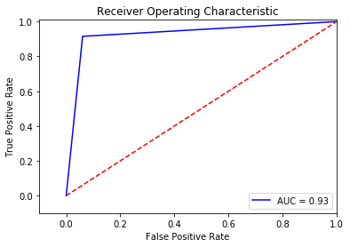

```python
from sklearn.metrics import roc_curve
from sklearn.metrics import auc

clf1 = LogisticRegression(C = 1)
clf1.fit(X_train, y_train)

y_pred = clf1.predict(X_test)

fpr, tpr, thresholds = roc_curve(y_test, y_pred)
roc_auc = auc(fpr,tpr)

plt.title('Receiver Operating Characteristic')
plt.plot(fpr, tpr, 'b',label='AUC = %0.2f'% roc_auc)
plt.legend(loc='lower right')
plt.plot([0,1],[0,1],'r--')
plt.xlim([-0.1,1.0])
plt.ylim([-0.1,1.01])
plt.ylabel('True Positive Rate')
plt.xlabel('False Positive Rate')
plt.show()
```

### One-class SVM

```python
from sklearn.preprocessing import StandardScaler
scaler = StandardScaler()
#CCD3['AmountS'] = scaler.fit_transform(CCD3.iloc[:,16].values.reshape(-1,1))

normal_data = CCD3[CCD3.Class==0].head(10000)
fraud_data = CCD3[CCD3.Class==1]

X = normal_data.drop(["Class", "Time", "Amount"],1)
y = normal_data["Class"]

X_train, X_test, y_train, y_test = train_test_split(X, y, train_size = .3, test_size = .7, random_state=42)

X_test = X_test.append(fraud_data.drop(["Class", "Time", "Amount"],1))

y_test = y_test.append(fraud_data["Class"])

display(X_test.head(5))
display(y_test.head(5))
```

|  | V1 | V2 | V3 | V4 | V5 | V6 | V7 | V9 | V10 | V11 | V12 | V14 | V16 | V17 | V18 | V19 |
| --- | --- | --- | --- | --- | --- | --- | --- | --- | --- | --- | --- | --- | --- | --- | --- | --- |
| 6256 | -0.462203 | 1.128481 | 1.815877 | 0.101183 | -0.036522 | -0.637001 | 0.524235 | 0.601576 | -0.517148 | 2.445215 | -1.752515 | 1.767185 | 0.301873 | 0.157318 | 0.338266 | 0.022534 |
| 4686 | -1.313887 | 0.331859 | 0.299060 | -0.823644 | 3.523227 | 2.999996 | -0.039735 | 0.594761 | -0.894791 | 0.571211 | -2.789271 | 1.800358 | 0.483176 | -0.409303 | 0.659507 | -0.672775 |
| 1733 | -0.316250 | 0.924568 | 2.498962 | 0.586195 | -0.290110 | -0.729195 | 0.731871 | -0.365708 | -0.334743 | 0.276679 | 0.795937 | -0.464164 | 0.078831 | -0.589469 | -0.160203 | -0.539367 |
| 4744 | 0.779512 | -0.543921 | 1.777621 | 1.528676 | -0.682021 | 2.036819 | -1.307011 | 2.528927 | -0.835476 | 1.231332 | -1.604637 | 0.952427 | -1.166705 | 1.767573 | -1.403276 | -2.283232 |
| 4523 | -0.135844 | 0.140612 | 1.480959 | -1.135779 | 0.213653 | 0.209191 | 0.517702 | 0.624232 | 0.326630 | 2.354727 | -3.697395 | -0.285862 | 0.789047 | 1.704233 | -0.606051 | 0.685474 |

```
6256    0
4686    0
1733    0
4744    0
4523    0
Name: Class, dtype: int64
```

```python
from sklearn.svm import OneClassSVM
from itertools import izip

def test_OCSVC(n,k,g):
    clf2 = OneClassSVM(nu = n, kernel = k, gamma = g)
    clf2.fit(X_train)

    y_pred = clf2.predict(X_test)

    binary_mapper = lambda x: 0 if x==-1 else 1
    vfunc = np.vectorize(binary_mapper)
    Y_pred = vfunc(y_pred)

    X_test_result = X_test
    X_test_result["y_test"] = y_test
    X_test_result["Y_pred"] = Y_pred


    tp, fp, fn, tn = 0.0, 0.0, 0.0, 0.0

    for i, row in X_test_result.iterrows():
        yt = X_test_result.get_value(i,"y_test")
        yp = X_test_result.get_value(i,"Y_pred")

        if yt == 0:
            if yt == yp:
                tp = tp+ 1
            else:
                fn = fn+ 1

        else:
            if yt == yp:
                tn = tn + 1
            else:
                fp = fp+ 1


    print "True pos: %s, true neg: %s, false pos: %s and false neg: %s" %(tp, tn, fp, fn)
    R = tp / (tp + fn)
    P = tp / (tp + fp)
    F2 = 2*R*P/(P+R)

    print "recall: ", R
    print "precision: ", P
    print "F2: ",F2
    print ""
```

```python
test_OCSVC(n = .95, k = 'rbf', g = .0001)
```

```
True pos: 6678.0, true neg: 0.0, false pos: 492.0 and false neg: 322.0
recall:  0.954
precision:  0.931380753138
F2:  0.942554693013
```

```python
test_OCSVC(n = .95, k = 'rbf', g = .0001)
```

```
True pos: 6678.0, true neg: 0.0, false pos: 492.0 and false neg: 322.0
recall:  0.954
precision:  0.931380753138
F2:  0.942554693013
```

```python
test_OCSVC(n = .15, k = 'linear', g = .1)
```

```
True pos: 1482.0, true neg: 34.0, false pos: 458.0 and false neg: 5518.0
recall:  0.211714285714
precision:  0.763917525773
F2:  0.331543624161
```

```python
test_OCSVC(n = .05, k = 'linear', g = .0001)
```

```
True pos: 3851.0, true neg: 107.0, false pos: 385.0 and false neg: 3149.0
recall:  0.550142857143
precision:  0.909112370161
F2:  0.685475258099
```

```python
test_OCSVC(n = .95, k = 'poly', g = .0001)
```

```
True pos: 4628.0, true neg: 332.0, false pos: 160.0 and false neg: 2372.0
recall:  0.661142857143
precision:  0.966583124478
F2:  0.785205293519
```

```python
test_OCSVC(n = .05, k = 'poly', g = .0001)
```

```
True pos: 6141.0, true neg: 131.0, false pos: 361.0 and false neg: 859.0
recall:  0.877285714286
precision:  0.944478621962
F2:  0.90964301585
```